# TUGAS 1

Pengerjaan dimulai dengan panggil library untuk analisis data deret waktu berikut.

```r
library("forecast")
```

```r
library("graphics")
library("TTR")
library("TSA")
```

## Import Dataset

```r
#install.packages("rio") #install jika belum ada
library(rio)
data<- import("https://raw.githubusercontent.com/fax17/MPDW/main/data/data.csv")
```

## Eksplorasi Data

Eksplorasi dilakukan dengan beberapa fungsi. Melihat data menggunakan fungsi `View()`, struktur data menggunakan fungsi `str()`, dan dimensi data menggunakan fungsi `dim()`.

```r
View(data)
str(data)
```

```
## 'data.frame':    271 obs. of  3 variables:
##  $ Periode: int  1 2 3 4 5 6 7 8 9 10 ...
##  $ bulan  : chr  "Januari" "Februari" "Maret" "April" ...
##  $ USD    : int  9450 9835 10400 11675 11058 11440 9525 8865 9675 10435 ...
```

```r
dim(data)
```

```
## [1] 271   3
```

Mengubah data agar terbaca sebagai data deret waktu dengan fungsi `ts()` .

```r
data.ts <- ts(data$USD)
```

Menampilkan ringkasan data dengan fungsi `summary()`.

```r
summary(data.ts)
```

```
##    Min. 1st Qu.  Median    Mean 3rd Qu.    Max.
##    8279    9175   10320   11346   13776   16367
```

Membuat plot data deret waktu

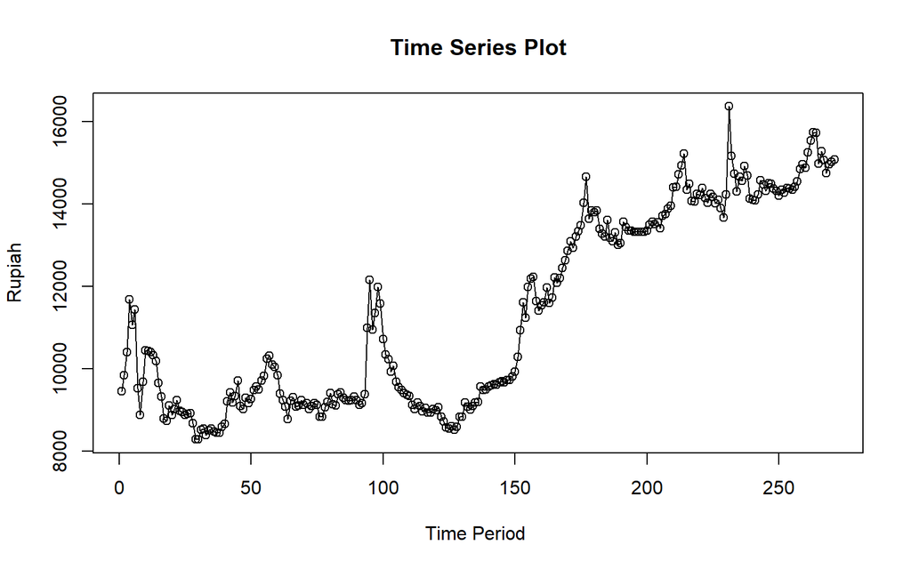

```r
ts.plot(data.ts, xlab="Time Period ", ylab="Rupiah",
        main = "Time Series Plot")
points(data.ts)
```

Dari keseluruhan data tersebut diambil sebagiannya saja untuk eksplorasi yakni sebanyak 120 amatan yang merupakan data 10 tahun dari 2012-2022.

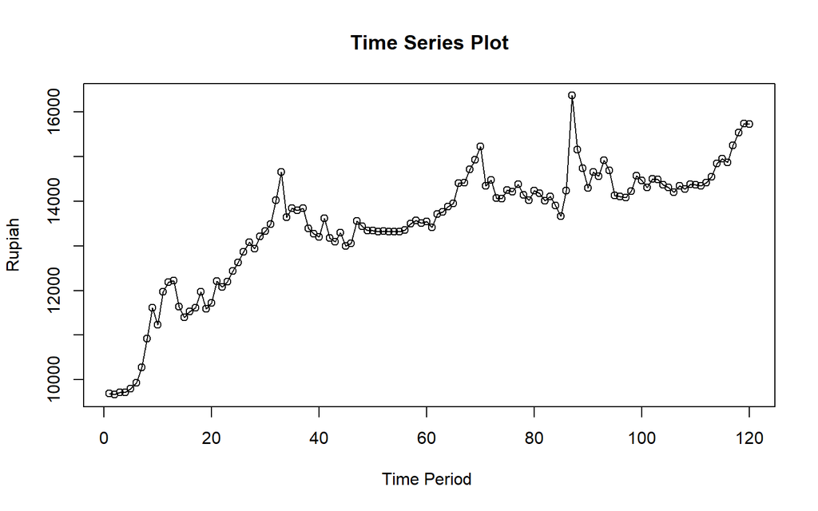

```r
#Eksplorasi sebagian data
datanew<- data[145:264,]
datanew.ts <- ts(datanew$USD)
ts.plot(datanew.ts, xlab="Time Period ", ylab="Rupiah",
        main = "Time Series Plot")
points(datanew.ts)
```

Selanjutnya akan dilakukan smoothing atau pemulusan pada data deret waktu yang dipilih, dan hasil eksplorasi menunjukan data tersebut berpola trend sehingga yang akan dicobakan adalah pemulusan dengan DMA (double moving average) dan DES (double eksponensial smoothing). Adapun sebelum memasuki pemulusan tersebut akan dilakukan pembagian data terlebih dahulu

### Pembagian Data

Pembagian data latih (train) dan data uji (test) dilakukan dengan perbandingan 85% data latih dan 15% data uji. Pembagian ini mengikuti keinginan pribadi dari peneliti agar data latih lebih dari 100 amatan dan ini menyesuaikan pada pola data yang ditunjukan.

```r
#membagi data latih dan data uji
train <- datanew[1:102,]
test <- datanew[103:120,]
train.ts <- ts(train$USD)
test.ts <- ts(test$USD)
```

### Eksplorasi Setiap Data

Selanjutnya dilakukan eksplorasi data yang dilakukan pada keseluruhan data, data latih serta data uji menggunakan plot data deret waktu.

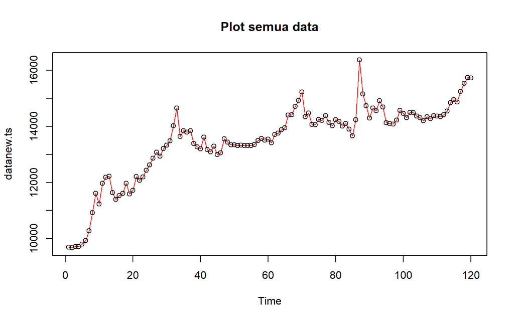

```r
#eksplorasi keseluruhan data
plot(datanew.ts, col="red",main="Plot semua data")
points(datanew.ts)
```

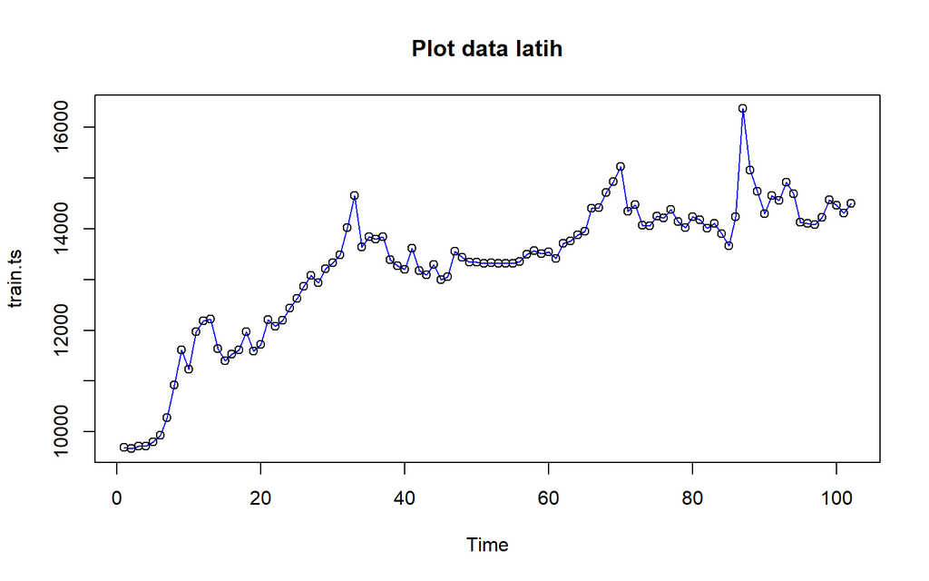

```r
#eksplorasi data latih
plot(train.ts, col="blue",main="Plot data latih")
points(train.ts)
```

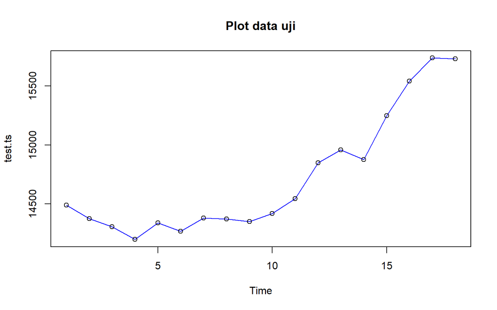

```r
#eksplorasi data uji
plot(test.ts, col="blue",main="Plot data uji")
points(test.ts)
```

Eksplorasi data juga dapat dilakukan menggunakan package `ggplot2` dengan terlebih dahulu memanggil library *package* `ggplot2`.

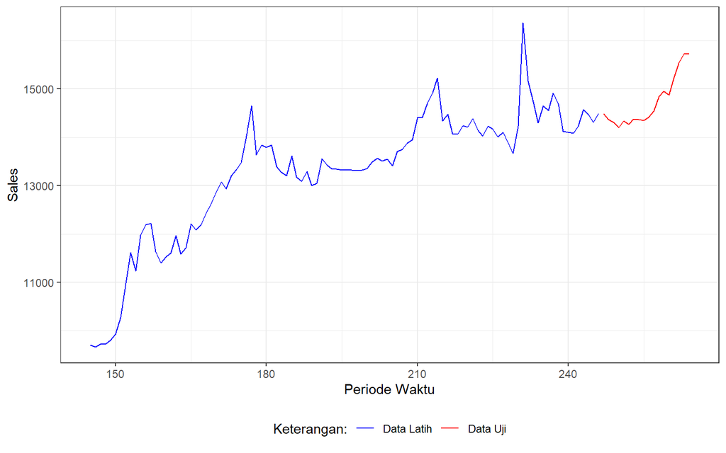

```r
#Eksplorasi dengan GGPLOT
library(ggplot2)
ggplot() +
  geom_line(data = train, aes(x = Periode, y = USD, col = "Data Latih")) +
  geom_line(data = test, aes(x = Periode, y = USD, col = "Data Uji")) +
  labs(x = "Periode Waktu", y = "Sales", color = "Legend") +
  scale_colour_manual(name="Keterangan:", breaks = c("Data Latih", "Data Uji"),
                      values = c("blue", "red")) +
  theme_bw() + theme(legend.position = "bottom",
                     plot.caption = element_text(hjust=0.5, size=12))
```

## Single Moving Average & Double Moving Average

Selanjutnya masuk ke metode pemulusan, metode pertama yang dilakukan adalah DMA dan pada metode ini perlu dilakukan SMA (Single Moving Average) terlebih dahulu.

### Single Moving Average (SMA)

Ide dasar dari Single Moving Average (SMA) adalah data suatu periode dipengaruhi oleh data periode sebelumnya. Metode pemulusan ini cocok digunakan untuk pola data stasioner atau konstan. Prinsip dasar metode pemulusan ini adalah data pemulusan pada periode ke-t merupakan rata rata dari m buah data pada periode ke-t hingga periode ke (t-m+1). Data pemulusan pada periode ke-t selanjutnya digunakan sebagai nilai peramalan pada periode ke t+1

Pemulusan menggunakan metode SMA dilakukan dengan fungsi `SMA()`. Dalam hal ini akan dilakukan pemulusan dengan parameter `m=4`.

```r
data.sma<-SMA(train.ts, n=4)
data.sma
```

```
## Time Series:
## Start = 1
## End = 102
## Frequency = 1
##   [1]       NA       NA       NA  9701.50  9727.50  9793.00  9932.75 10233.25
##   [9] 10686.00 11012.25 11437.00 11753.25 11906.50 12006.50 11863.25 11699.00
##  [17] 11545.25 11629.00 11675.75 11722.00 11872.25 11900.50 12051.75 12232.50
##  [25] 12335.75 12531.00 12753.00 12877.25 13023.75 13141.00 13240.25 13512.75
##  [33] 13874.25 13951.00 14040.75 13982.75 13780.00 13719.00 13578.00 13430.25
##  [41] 13372.50 13318.75 13273.25 13297.25 13143.00 13110.75 13228.00 13262.00
##  [49] 13348.25 13422.25 13361.75 13334.50 13329.00 13322.00 13322.50 13328.50
##  [57] 13371.25 13434.50 13482.25 13531.50 13511.75 13545.50 13606.00 13688.25
##  [65] 13822.75 13997.00 14161.25 14369.75 14614.25 14820.00 14801.50 14744.00
##  [73] 14529.75 14238.50 14214.75 14148.25 14226.50 14246.25 14191.75 14197.25
##  [81] 14144.50 14111.25 14130.25 14046.25 13918.25 13974.75 14541.00 14855.00
##  [89] 15122.75 15139.75 14711.25 14560.50 14606.75 14703.75 14572.50 14460.25
##  [97] 14251.75 14136.50 14247.50 14338.25 14394.75 14461.50
```

Data pemulusan pada periode ke-t selanjutnya digunakan sebagai nilai peramalan pada periode ke t+1 sehingga hasil peramalan 1 periode kedepan adalah sebagai berikut.

```r
data.ramal<-c(NA,data.sma)
data.ramal #forecast 1 periode ke depan
```

```
##   [1]       NA       NA       NA       NA  9701.50  9727.50  9793.00  9932.75
##   [9] 10233.25 10686.00 11012.25 11437.00 11753.25 11906.50 12006.50 11863.25
##  [17] 11699.00 11545.25 11629.00 11675.75 11722.00 11872.25 11900.50 12051.75
##  [25] 12232.50 12335.75 12531.00 12753.00 12877.25 13023.75 13141.00 13240.25
##  [33] 13512.75 13874.25 13951.00 14040.75 13982.75 13780.00 13719.00 13578.00
##  [41] 13430.25 13372.50 13318.75 13273.25 13297.25 13143.00 13110.75 13228.00
##  [49] 13262.00 13348.25 13422.25 13361.75 13334.50 13329.00 13322.00 13322.50
##  [57] 13328.50 13371.25 13434.50 13482.25 13531.50 13511.75 13545.50 13606.00
##  [65] 13688.25 13822.75 13997.00 14161.25 14369.75 14614.25 14820.00 14801.50
##  [73] 14744.00 14529.75 14238.50 14214.75 14148.25 14226.50 14246.25 14191.75
##  [81] 14197.25 14144.50 14111.25 14130.25 14046.25 13918.25 13974.75 14541.00
##  [89] 14855.00 15122.75 15139.75 14711.25 14560.50 14606.75 14703.75 14572.50
##  [97] 14460.25 14251.75 14136.50 14247.50 14338.25 14394.75 14461.50
```

Selanjutnya akan dilakukan peramalan sejumlah data uji yaitu 18 periode. Pada metode SMA, hasil peramalan 18 periode ke depan akan bernilai sama dengan hasil peramalan 1 periode kedepan. Dalam hal ini akan dilakukan pengguabungan data aktual train, data hasil pemulusan dan data hasil ramalan 18 periode kedepan.

```r
data.gab<-cbind(aktual=c(train.ts,rep(NA,18)),pemulusan=c(data.sma,rep(NA,18)),ramalan=c(data.ramal,rep(data.ramal[length(data.ramal)],17)))
data.gab #forecast 24 periode ke depan
```

```
##        aktual pemulusan  ramalan
##   [1,]   9698        NA       NA
##   [2,]   9667        NA       NA
##   [3,]   9719        NA       NA
##   [4,]   9722   9701.50       NA
##   [5,]   9802   9727.50  9701.50
##   [6,]   9929   9793.00  9727.50
##   [7,]  10278   9932.75  9793.00
##   [8,]  10924  10233.25  9932.75
##   [9,]  11613  10686.00 10233.25
##  [10,]  11234  11012.25 10686.00
##  [11,]  11977  11437.00 11012.25
##  [12,]  12189  11753.25 11437.00
##  [13,]  12226  11906.50 11753.25
##  [14,]  11634  12006.50 11906.50
```

[output cut: 106 more lines]

Adapun plot data deret waktu dari hasil peramalan yang dilakukan adalah sebagai berikut.

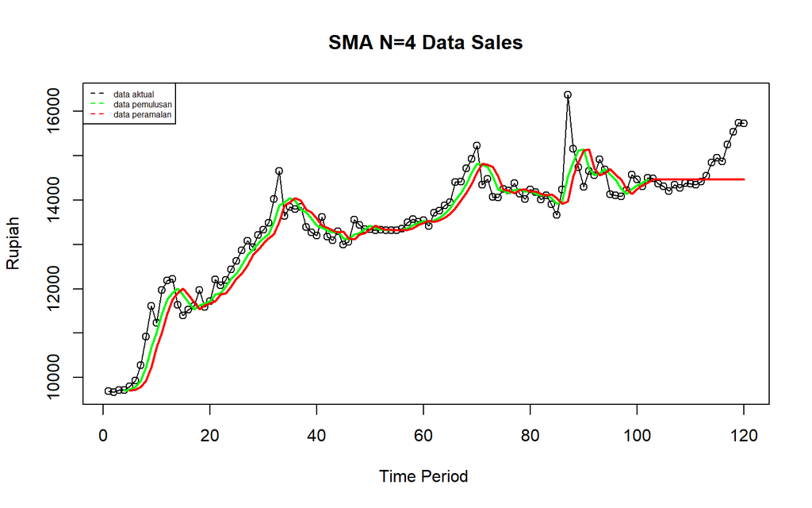

```r
ts.plot(datanew.ts, xlab="Time Period ", ylab="Rupiah", main= "SMA N=4 Data Sales")
points(datanew.ts)
lines(data.gab[,2],col="green",lwd=2)
lines(data.gab[,3],col="red",lwd=2)
legend("topleft",c("data aktual","data pemulusan","data peramalan"), lty=8, col=c("black","green","red"), cex=0.5)
```

Setelah didapat hasil dari SMA, barulah kita berlanjut ke DMA.

### Double Moving Average (DMA)

Metode pemulusan Double Moving Average (DMA) pada dasarnya mirip dengan SMA. Namun demikian, metode ini lebih cocok digunakan untuk pola data trend. Proses pemulusan dengan rata rata dalam metode ini dilakukan sebanyak 2 kali.

```r
dma <- SMA(data.sma, n = 4)
At <- 2*data.sma - dma
Bt <- 2/(4-1)*(data.sma - dma)
data.dma<- At+Bt
data.ramal2<- c(NA, data.dma)

t = 1:18
f = c()

for (i in t) {
  f[i] = At[length(At)] + Bt[length(Bt)]*(i)
}

data.gab2 <- cbind(aktual = c(train.ts,rep(NA,18)), pemulusan1 = c(data.sma,rep(NA,18)),pemulusan2 = c(data.dma, rep(NA,18)),At = c(At, rep(NA,18)), Bt = c(Bt,rep(NA,18)),ramalan = c(data.ramal2, f[-1]))
data.gab2
```

```
##        aktual pemulusan1 pemulusan2       At          Bt  ramalan
##   [1,]   9698         NA         NA       NA          NA       NA
##   [2,]   9667         NA         NA       NA          NA       NA
##   [3,]   9719         NA         NA       NA          NA       NA
##   [4,]   9722    9701.50         NA       NA          NA       NA
##   [5,]   9802    9727.50         NA       NA          NA       NA
##   [6,]   9929    9793.00         NA       NA          NA       NA
##   [7,]  10278    9932.75   10172.85 10076.81   96.041667       NA
##   [8,]  10924   10233.25   10752.62 10544.88  207.750000 10172.85
##   [9,]  11613   10686.00   11560.58 11210.75  349.833333 10752.62
##  [10,]  11234   11012.25   11922.56 11558.44  364.125000 11560.58
##  [11,]  11977   11437.00   12428.46 12031.88  396.583333 11922.56
##  [12,]  12189   11753.25   12638.46 12284.38  354.083333 12428.46
##  [13,]  12226   11906.50   12538.58 12285.75  252.833333 12638.46
##  [14,]  11634   12006.50   12390.98 12237.19  153.791667 12538.58
```

[output cut: 106 more lines]

Hasil pemulusan menggunakan metode DMA divisualisasikan sebagai berikut

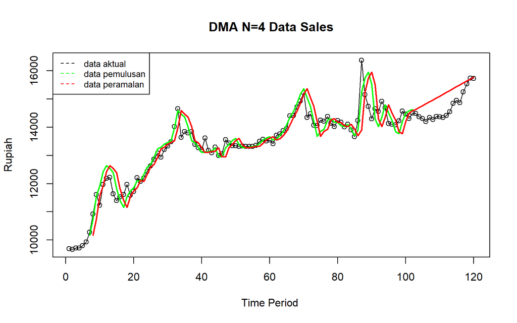

```r
ts.plot(datanew.ts, xlab="Time Period ", ylab="Rupiah", main= "DMA N=4 Data Sales")
points(datanew.ts)
lines(data.gab2[,3],col="green",lwd=2)
lines(data.gab2[,6],col="red",lwd=2)
legend("topleft",c("data aktual","data pemulusan","data peramalan"), lty=8, col=c("black","green","red"), cex=0.8)
```

Selanjutnya dilakukan perhitungan akurasi yakni dengan ukuran akurasi *Sum Squares Error* (SSE), *Mean Square Error* (MSE) dan *Mean Absolute Percentage Error* (MAPE). Perhitungan akurasi dilakukan baik pada data latih maupun pada data uji.

```r
#Menghitung nilai keakuratan data latih
error_train.dma = train.ts-data.ramal2[1:length(train.ts)]
SSE_train.dma = sum(error_train.dma[8:length(train.ts)]^2)
MSE_train.dma = mean(error_train.dma[8:length(train.ts)]^2)
MAPE_train.dma = mean(abs((error_train.dma[8:length(train.ts)]/train.ts[8:length(train.ts)])*100))

akurasi_train.dma <- matrix(c(SSE_train.dma, MSE_train.dma, MAPE_train.dma))
row.names(akurasi_train.dma)<- c("SSE", "MSE", "MAPE")
colnames(akurasi_train.dma) <- c("Akurasi m = 4")
akurasi_train.dma
```

```
##      Akurasi m = 4
## SSE   2.431937e+07
## MSE   2.559933e+05
## MAPE  2.448192e+00
```

Perhitungan akurasi pada data latih menggunakan nilai MAPE menghasilkan nilai MAPE yang kurang dari 10 sehingga dikategorikan sangat baik. Selanjutnya, perhitungan nilai akurasi dilakukan pada data uji.

```r
#Menghitung nilai keakuratan data uji
error_test.dma = test.ts-data.gab2[103:120,6]
SSE_test.dma = sum(error_test.dma^2)
MSE_test.dma = mean(error_test.dma^2)
MAPE_test.dma = mean(abs((error_test.dma/test.ts*100)))

akurasi_test.dma <- matrix(c(SSE_test.dma, MSE_test.dma, MAPE_test.dma))
row.names(akurasi_test.dma)<- c("SSE", "MSE", "MAPE")
colnames(akurasi_test.dma) <- c("Akurasi m = 4")
akurasi_test.dma
```

```
##      Akurasi m = 4
## SSE   5.427430e+06
## MSE   3.015239e+05
## MAPE  3.336995e+00
```

Selanjutnya dicobakan teknik pemulusan kedua yakni DES.

## Double Exponential Smoothing

Metode *Exponential Smoothing* adalah metode pemulusan dengan melakukan pembobotan menurun secara eksponensial. Nilai yang lebih baru diberi bobot yang lebih besar dari nilai terdahulu. Terdapat satu atau lebih parameter pemulusan yang ditentukan secara eksplisit, dan hasil pemilihan parameter tersebut akan menentukan bobot yang akan diberikan pada nilai pengamatan. Ada dua macam model, yaitu model tunggal atau biasa disebut *Single Exponential Smoothing (SES)* dan model ganda yang disebut *Double Exponential Smoothing (DES)*. Pada pemulusan ini dicobakan DES karena SES merupakan metode pemulusan yang tepat digunakan untuk data dengan pola stasioner atau konstan sementara DES digunakan untuk data yang memiliki pola tren. Metode DES adalah metode semacam SES, hanya saja dilakukan dua kali, yaitu pertama untuk tahapan ‘level’ dan kedua untuk tahapan ‘tren’. Pemulusan menggunakan metode ini akan menghasilkan peramalan tidak konstan untuk periode berikutnya. Adapun pemulusan dengan metode DES kali ini akan menggunakan fungsi `HoltWinters()`. Disini saya mencobakan beberapa pemulusan dengan lamda dan gamma berbeda kemudian dilakukan des optimumnya dengan lamda dan gamma yang dikosongkan agar otomatis terisi.

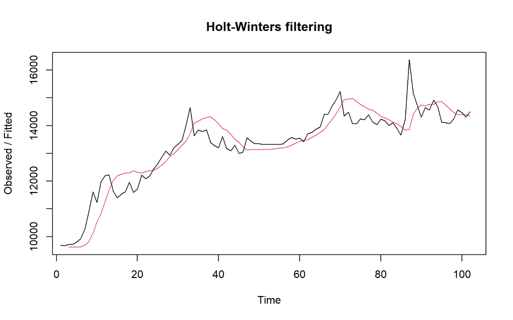

```r
#Lamda=0.2 dan gamma=0.2
des.1<- HoltWinters(train.ts, gamma = FALSE, beta = 0.2, alpha = 0.2)
plot(des.1)
```

```r
#ramalan
ramalandes1<- forecast(des.1, h=18)
ramalandes1
```

```
##     Point Forecast    Lo 80    Hi 80    Lo 95    Hi 95
## 103       14350.73 13648.98 15052.48 13277.50 15423.96
## 104       14327.58 13605.90 15049.25 13223.87 15431.29
## 105       14304.43 13556.48 15052.38 13160.54 15448.31
## 106       14281.28 13500.35 15062.21 13086.95 15475.61
## 107       14258.13 13437.36 15078.91 13002.86 15513.40
## 108       14234.98 13367.53 15102.43 12908.34 15561.63
## 109       14211.83 13291.07 15132.59 12803.65 15620.02
## 110       14188.68 13208.24 15169.12 12689.23 15688.14
## 111       14165.53 13119.39 15211.68 12565.59 15765.48
## 112       14142.38 13024.86 15259.90 12433.28 15851.48
## 113       14119.23 12925.03 15313.44 12292.85 15945.62
## 114       14096.09 12820.22 15371.95 12144.81 16047.36
## 115       14072.94 12710.75 15435.12 11989.65 16156.22
## 116       14049.79 12596.91 15502.66 11827.81 16271.76
## 117       14026.64 12478.97 15574.31 11659.68 16393.59
## 118       14003.49 12357.14 15649.83 11485.62 16521.35
## 119       13980.34 12231.65 15729.03 11305.95 16654.73
## 120       13957.19 12102.66 15811.72 11120.93 16793.44
```

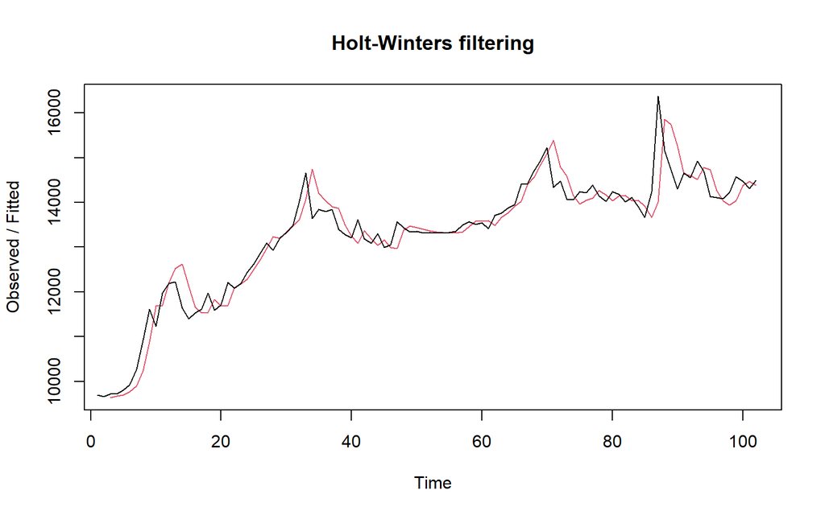

```r
#Lamda=0.6 dan gamma=0.3
des.2<- HoltWinters(train.ts, gamma = FALSE, beta = 0.3, alpha = 0.6)
plot(des.2)
```

```r
#ramalan
ramalandes2<- forecast(des.2, h=18)
ramalandes2
```

```
##     Point Forecast     Lo 80    Hi 80     Lo 95    Hi 95
## 103       14480.66 13931.245 15030.07 13640.405 15320.91
## 104       14510.05 13813.270 15206.83 13444.418 15575.68
## 105       14539.44 13665.548 15413.33 13202.937 15875.94
## 106       14568.83 13493.669 15643.99 12924.512 16213.15
## 107       14598.22 13301.334 15895.11 12614.802 16581.65
## 108       14627.62 13091.031 16164.20 12277.612 16977.62
## 109       14657.01 12864.511 16449.50 11915.621 17398.39
## 110       14686.40 12623.069 16749.73 11530.808 17841.99
## 111       14715.79 12367.701 17063.88 11124.698 18306.88
## 112       14745.18 12099.209 17391.15 10698.516 18791.85
## 113       14774.57 11818.251 17730.90 10253.268 19295.88
## 114       14803.97 11525.384 18082.55  9789.808 19818.12
## 115       14833.36 11221.088 18445.63  9308.868 20357.85
## 116       14862.75 10905.782 18819.71  8811.091 20914.41
## 117       14892.14 10579.840 19204.44  8297.046 21487.24
## 118       14921.53 10243.593 19599.47  7767.242 22075.82
## 119       14950.92  9897.344 20004.50  7222.140 22679.71
## 120       14980.32  9541.366 20419.26  6662.161 23298.47
```

Selanjutnya jika ingin membandingkan plot data latih dan data uji adalah sebagai berikut.

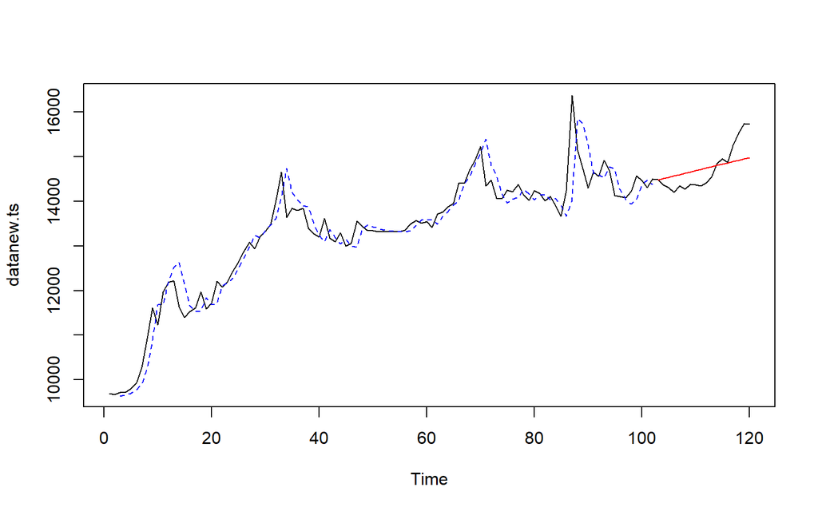

```r
#Visually evaluate the prediction
plot(datanew.ts)
lines(des.2$fitted[,1], lty=2, col="blue")
lines(ramalandes2$mean, col="red")
```

Untuk mendapatkan nilai parameter optimum dari DES, argumen `alpha` dan `beta` dapat dibuat `NULL` seperti berikut.

```r
#Lamda dan gamma optimum
des.opt<- HoltWinters(train.ts, gamma = FALSE)
des.opt
```

```
## Holt-Winters exponential smoothing with trend and without seasonal component.
##
## Call:
## HoltWinters(x = train.ts, gamma = FALSE)
##
## Smoothing parameters:
##  alpha: 0.8671094
##  beta : 0.01435857
##  gamma: FALSE
##
## Coefficients:
##         [,1]
## a 14476.6333
## b    17.3523
```

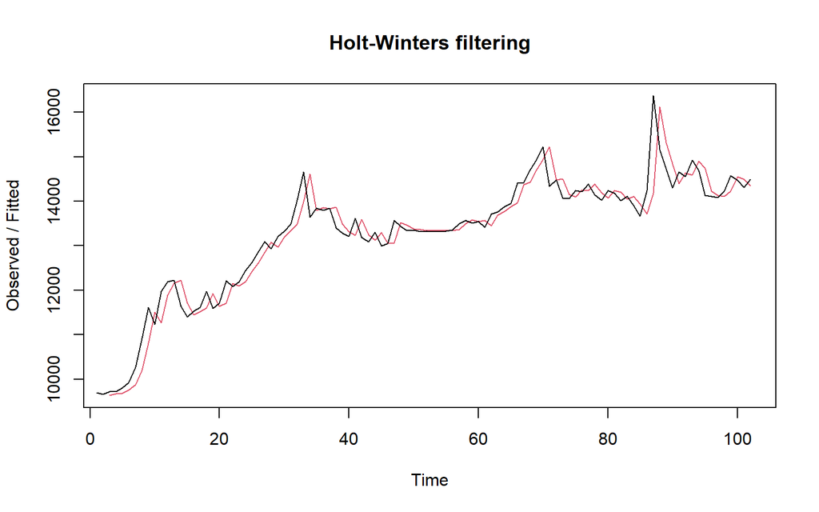

```r
plot(des.opt)
```

```r
#ramalan
ramalandesopt<- forecast(des.opt, h=18)
ramalandesopt
```

```
##     Point Forecast    Lo 80    Hi 80    Lo 95    Hi 95
## 103       14493.99 13991.97 14996.00 13726.22 15261.75
## 104       14511.34 13842.77 15179.91 13488.85 15533.83
## 105       14528.69 13724.01 15333.37 13298.03 15759.35
## 106       14546.04 13622.10 15469.99 13132.99 15959.10
## 107       14563.39 13531.14 15595.65 12984.69 16142.10
## 108       14580.75 13447.95 15713.54 12848.28 16313.21
## 109       14598.10 13370.59 15825.61 12720.79 16475.41
## 110       14615.45 13297.78 15933.13 12600.24 16630.66
## 111       14632.80 13228.60 16037.01 12485.26 16780.35
## 112       14650.16 13162.40 16137.91 12374.83 16925.48
## 113       14667.51 13098.68 16236.34 12268.19 17066.82
## 114       14684.86 13037.05 16332.67 12164.75 17204.97
## 115       14702.21 12977.19 16427.24 12064.02 17340.41
## 116       14719.57 12918.86 16520.27 11965.63 17473.50
## 117       14736.92 12861.86 16611.98 11869.26 17604.58
## 118       14754.27 12806.00 16702.54 11774.65 17733.89
## 119       14771.62 12751.15 16792.10 11681.58 17861.67
## 120       14788.97 12697.18 16880.77 11589.85 17988.09
```

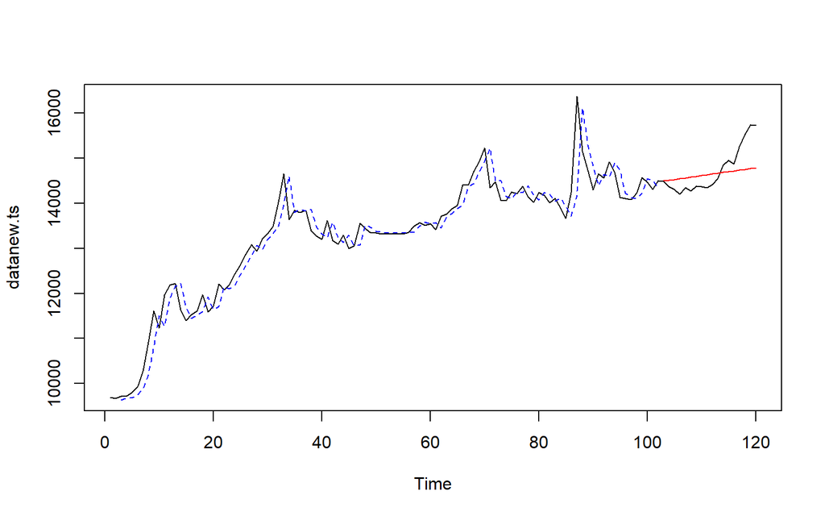

```r
#Visually evaluate the prediction optimum
plot(datanew.ts)
lines(des.opt$fitted[,1], lty=2, col="blue")
lines(ramalandesopt$mean, col="red")
```

Selanjutnya akan dilakukan perhitungan akurasi pada data latih maupun data uji dengan ukuran akurasi SSE, MSE dan MAPE.

#### Akurasi Data Latih

```r
#Akurasi Data Training
ssedes.train1<-des.1$SSE
msedes.train1<-ssedes.train1/length(train.ts)
sisaandes1<-ramalandes1$residuals
head(sisaandes1)
```

```
## Time Series:
## Start = 1
## End = 6
## Frequency = 1
## [1]       NA       NA  83.0000  97.0800 181.4608 288.7070
```

```r
mapedes.train1 <- sum(abs(sisaandes1[3:length(train.ts)]/train.ts[3:length(train.ts)])
                      *100)/length(train.ts)

akurasides.1 <- matrix(c(ssedes.train1,msedes.train1,mapedes.train1))
row.names(akurasides.1)<- c("SSE", "MSE", "MAPE")
colnames(akurasides.1) <- c("Akurasi lamda=0.2 dan gamma=0.2")
akurasides.1
```

```
##      Akurasi lamda=0.2 dan gamma=0.2
## SSE                     2.968458e+07
## MSE                     2.910253e+05
## MAPE                    3.058644e+00
```

```r
ssedes.train2<-des.2$SSE
msedes.train2<-ssedes.train2/length(train.ts)
sisaandes2<-ramalandes2$residuals
head(sisaandes2)
```

```
## Time Series:
## Start = 1
## End = 6
## Frequency = 1
## [1]       NA       NA  83.0000  52.2600 107.5572 157.3158
```

```r
mapedes.train2 <- sum(abs(sisaandes2[3:length(train.ts)]/train.ts[3:length(train.ts)])
                      *100)/length(train.ts)

akurasides.2 <- matrix(c(ssedes.train2,msedes.train2,mapedes.train2))
row.names(akurasides.2)<- c("SSE", "MSE", "MAPE")
colnames(akurasides.2) <- c("Akurasi lamda=0.6 dan gamma=0.3")
akurasides.2
```

```
##      Akurasi lamda=0.6 dan gamma=0.3
## SSE                     1.819638e+07
## MSE                     1.783959e+05
## MAPE                    1.954768e+00
```

Hasil akurasi dari data latih didapatkan skenario 2 dengan lamda=0.6 dan gamma=0.3 memiliki hasil yang lebih baik. Namun untuk kedua skenario dapat dikategorikan peramalan sangat baik berdasarkan nilai MAPE-nya.

#### Akurasi Data Uji

```r
#Akurasi Data Testing
selisihdes1<-ramalandes1$mean-test$USD
selisihdes1
```

```
## Time Series:
## Start = 103
## End = 120
## Frequency = 1
##  [1]  -140.272399   -46.421712    -2.571026    82.279660   -81.869654
##  [6]   -34.018968  -169.168281  -182.317595  -183.466909  -275.616223
## [11]  -424.765537  -751.914850  -885.064164  -825.213478 -1220.362792
## [16] -1538.512106 -1756.661419 -1773.810733
```

```r
SSEtestingdes1<-sum(selisihdes1^2)
MSEtestingdes1<-SSEtestingdes1/length(test$USD)
MAPEtestingdes1<-sum(abs(selisihdes1/test$USD)*100)/length(test$USD)

selisihdes2<-ramalandes2$mean-test$USD
selisihdes2
```

```
## Time Series:
## Start = 103
## End = 120
## Frequency = 1
##  [1]  -10.34341  136.04829  232.43999  369.83169  258.22338  358.61508
##  [7]  276.00678  315.39848  366.79018  327.18188  230.57358  -44.03472
## [13] -124.64302  -12.25132 -354.85962 -620.46792 -786.07622 -750.68452
```

```r
SSEtestingdes2<-sum(selisihdes2^2)
MSEtestingdes2<-SSEtestingdes2/length(test$USD)
MAPEtestingdes2<-sum(abs(selisihdes2/test$USD)*100)/length(test$USD)

selisihdesopt<-ramalandesopt$mean-test$USD
selisihdesopt
```

```
## Time Series:
## Start = 103
## End = 120
## Frequency = 1
##  [1]    2.985636  137.337935  221.690235  347.042534  223.394834  311.747134
##  [7]  217.099433  244.451733  283.804032  232.156332  123.508631 -163.139069
## [13] -255.786770 -155.434470 -510.082171 -787.729871 -965.377572 -942.025272
```

```r
SSEtestingdesopt<-sum(selisihdesopt^2)
MSEtestingdesopt<-SSEtestingdesopt/length(test$USD)
MAPEtestingdesopt<-sum(abs(selisihdesopt/test$USD)*100)/length(test$USD)

akurasitestingdes <-
  matrix(c(SSEtestingdes1,MSEtestingdes1,MAPEtestingdes1,SSEtestingdes2,MSEtestingdes2,
           MAPEtestingdes2,SSEtestingdesopt,MSEtestingdesopt,MAPEtestingdesopt),
         nrow=3,ncol=3)
row.names(akurasitestingdes)<- c("SSE", "MSE", "MAPE")
colnames(akurasitestingdes) <- c("des ske1","des ske2","des opt")
akurasitestingdes
```

```
##          des ske1     des ske2      des opt
## SSE  1.250664e+07 2.585081e+06 3.408400e+06
## MSE  6.948131e+05 1.436156e+05 1.893556e+05
## MAPE 3.784652e+00 2.076933e+00 2.263921e+00
```

Sekian & Terimakasih